# portfolio 8

2023-04-18

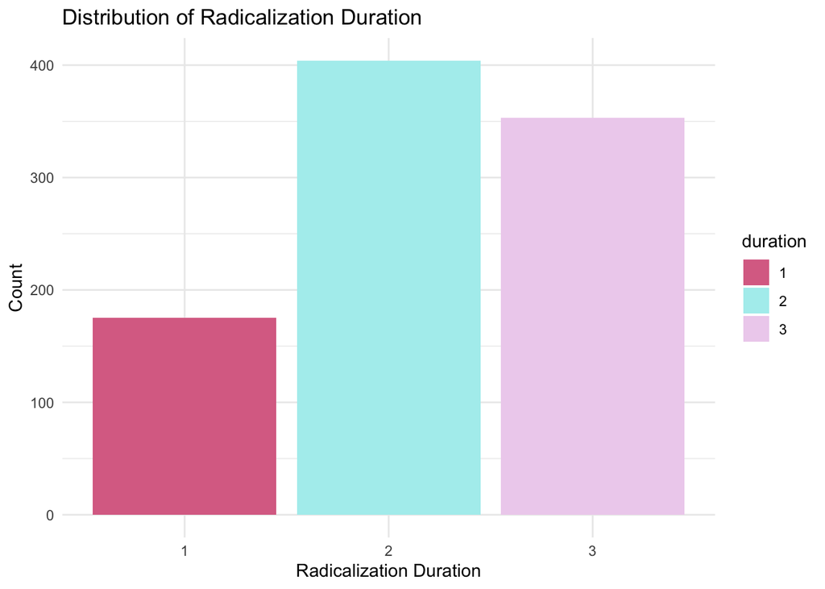

```r
duration_counts <- table(df$Rad_duration)

duration_df <- data.frame(duration = names(duration_counts),
                          count = as.numeric(duration_counts))

duration_df$duration <- factor(duration_df$duration, levels = c("1", "2", "3"))

ggplot(duration_df, aes(x = duration, y = count, fill = duration)) +
  geom_bar(stat = "identity") +
  labs(x = "Radicalization Duration",
       y = "Count",
       title = "Distribution of Radicalization Duration") +
  scale_fill_manual(values = c("palevioletred", "paleturquoise", "thistle2")) +
  theme_minimal()
```

1 = Short (less than a year) 2 = Medium (between one and five years) 3 = Long (more than five years)

Most radicalization took 1-5 years before violent action, though many also took five+ years. I was honestly surprised the radicalizaton process prior to violence was so lengthy.

```r
df%>%
  count(Event_Influence1) %>%
  arrange(desc(n))
```

```
## # A tibble: 10 × 2
##    Event_Influence1     n
##               <dbl> <int>
##  1               NA  1109
##  2                0   689
##  3                8   176
##  4                2    79
##  5                1    63
##  6                7    41
##  7                5    40
##  8                6    21
##  9                4     6
## 10                3     2
```

Of the terrorists who cited a specific event for precipitating their attacks, the top events were the Vietnam War, 9/11, and Arab Spring/Syrian Civil War. The vast majority did not cite a specific even as spurring on their attacks.

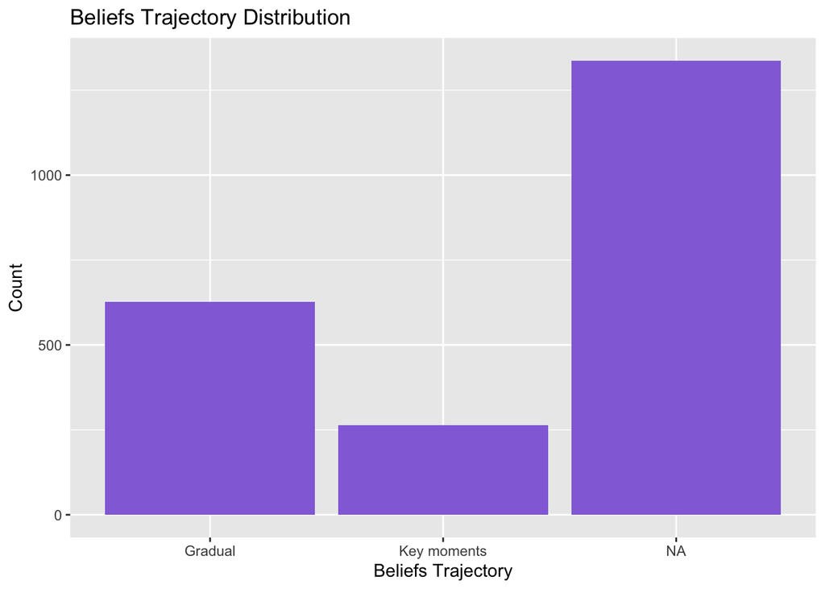

```r
ggplot(df, aes(x = factor(Beliefs_Trajectory))) +
  geom_bar(fill = "mediumpurple") +
  labs(title = "Beliefs Trajectory Distribution", x = "Beliefs Trajectory", y = "Count") +
  scale_x_discrete(labels = c("Gradual", "Key moments"))
```

In line with the previous analyses, it is not surprising that of the data we have (excluding NA) most people cited a gradual belief radicalization.

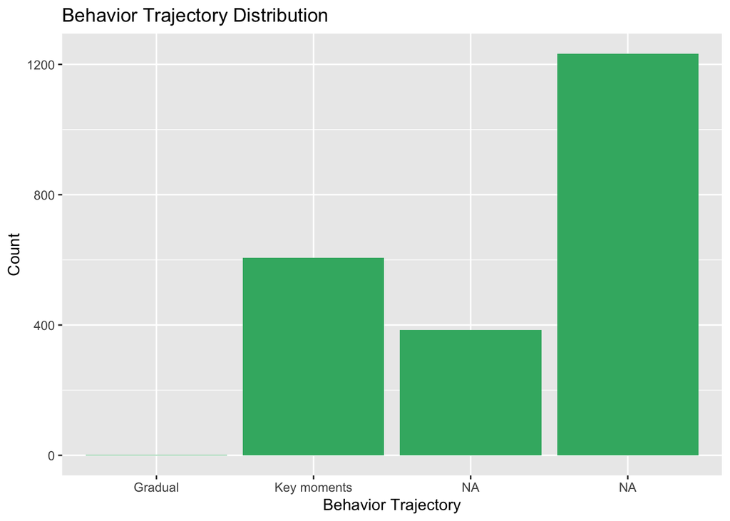

```r
ggplot(df, aes(x = factor(Behaviors_Trajectory))) +
  geom_bar(fill = "mediumseagreen") +
  labs(title = "Behavior Trajectory Distribution", x = "Behavior Trajectory", y = "Count") +
  scale_x_discrete(labels = c("Gradual", "Key moments"))
```

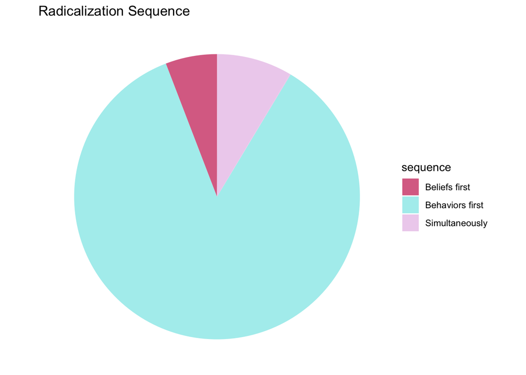

```r
df_filtered <- df[!is.na(df$Radicalization_Sequence),]

counts <- table(df_filtered$Radicalization_Sequence)

df_counts <- data.frame(sequence = names(counts), count = as.numeric(counts))

df_counts$sequence <- ifelse(df_counts$sequence == "1", "Beliefs first",
                             ifelse(df_counts$sequence == "2", "Behaviors first", "Simultaneously"))


ggplot(df_counts, aes(x="", y=count, fill=sequence)) +
  geom_bar(stat="identity", width=1) +
  coord_polar("y", start=0) +
  scale_fill_manual(values=c("palevioletred", "paleturquoise", "thistle2"),
                    labels=c("Beliefs first", "Behaviors first", "Simultaneously")) +
  theme_void() +
  labs(title="Radicalization Sequence")
```

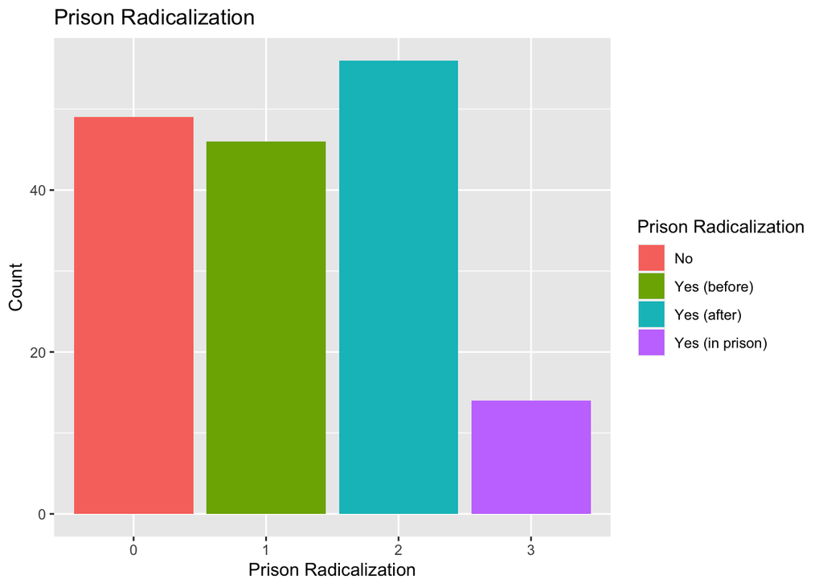

```r
df_filtered <- subset(df, !is.na(Prison_Radicalize))

ggplot(df_filtered, aes(x = factor(Prison_Radicalize), fill = factor(Prison_Radicalize))) +
  geom_bar() +
  scale_fill_discrete(name = "Prison Radicalization", labels = c("No", "Yes (before)", "Yes (after)", "Yes (in prison)")) +
  labs(title = "Prison Radicalization") +
  xlab("Prison Radicalization") +
  ylab("Count")
```

0 = No, individual had reached maximum level of radicalization (in both behaviors and beliefs) before prison 1 = Yes, but radicalization had begun (in either behaviors or belief) before prison 26 2 = Yes, but radicalization reached maximum level (in both behaviors and belief) after prison 3 = Yes, radicalization began and reached maximum level in prison